# Practical Machine Learning Week 4 Prediction Assignment

Unsa Jamil

8/21/2019

## Introduction

Using devices such as **Jawbone Up,Nike FuelBand and Fibit** it is now possible to collect a large amount of data about personal activity relatively inexpensively.These type of devices are part of the quantified self movement,a group of enthusiasts who take measurements about themselves regularly to improve their health to find patterns in thier behaviour or because they are tech greeks.One thing that people regularly do is quantify how much of a particular activity they do,but they rarely quantify how well they do it. In this project our goal will be to use data from accelerometers on the **belt,forearm,arm and dumbell of 6 participants**.They were asked to perform barbell lifts correctly and incorrectly in 5 different ways.More information is available from the website here : (http://web.archive.org/web/20161224072740/http:/groupware.les.inf.puc-rio.br/har)

## Data Descriptions

- The **training data** for this project are available here : (https://d396qusza40orc.cloudfront.net/predmachlearn/pml-training.csv)
- The **test data** are available here: (https://d396qusza40orc.cloudfront.net/predmachlearn/pml-testing.csv)
- The **data** for this project come from this source: (http://web.archive.org/web/20161224072740/http:/groupware.les.inf.puc-rio.br/har)

## Loading Libraries

```r
library(caret)
```

```r
library(rpart)
library(rpart.plot)
library(rattle)
library(randomForest)
library(RColorBrewer)
library(RGtk2)
library(gbm)
```

## Loading Train And Test Data

```r
urlTrain <- "https://d396qusza40orc.cloudfront.net/predmachlearn/pml-training.csv"
urlTest <- "https://d396qusza40orc.cloudfront.net/predmachlearn/pml-testing.csv"
```

## Reading Train And Test Data

```r
trainData <- read.csv(url(urlTrain))
testData <- read.csv(url(urlTest))
dim(trainData)
```

```
## [1] 19622   160
```

```r
dim(testData)
```

```
## [1]  20 160
```

## Data Cleansing

- Removing variables which are having nearly **Zero Variance**

```r
zeroVar <- nearZeroVar(trainData)
trainingData <- trainData[,-zeroVar]
testingData <- testData[,-zeroVar]
```

## Removing **NA Values of variables**

```r
naValues <- sapply(trainingData,function(x) mean(is.na(x))) > 0.95
trainingData <- trainingData[,naValues == FALSE]
testingData <- testingData[,naValues == FALSE]
```

## Removing the **first 7 variables which are Non-Numeric**

```r
trainingData <- trainingData[,8:59]
testingData <- testingData[,8:59]
dim(trainingData)
```

```
## [1] 19622    52
```

```r
dim(testingData)
```

```
## [1] 20 52
```

## Data Partioning

In this we will seggregate our **trainingData** into **2 parts training(60% of data) and testing(40% of the day)** validation set.

```r
pd <- createDataPartition(trainingData$classe, p=0.6, list = FALSE)
pd <- createDataPartition(trainingData$classe, p=0.6, list = FALSE)
training <- trainingData[pd,]
testing <- trainingData[-pd,]
```

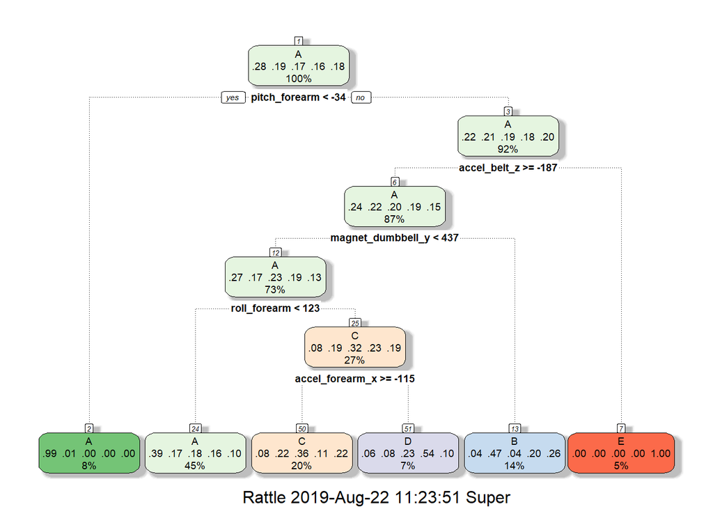

```r
dataModel <- train(classe~.,data = training,method="rpart")
fancyRpartPlot(dataModel$finalModel)
```

* Prediction

```r
set.seed(21243)
dataPrediction <- predict(dataModel,testing)
confusionMatrix(dataPrediction,testing$classe)
```

```
## Confusion Matrix and Statistics
##
##           Reference
## Prediction    A    B    C    D    E
##          A 2033  654  634  565  323
##          B   35  520   48  249  290
##          C  124  295  569  184  339
##          D   35   49  117  288   59
##          E    5    0    0    0  431
##
## Overall Statistics
##
##                Accuracy : 0.4895
##                  95% CI : (0.4784, 0.5007)
##     No Information Rate : 0.2845
##     P-Value [Acc > NIR] : < 2.2e-16
##
##                   Kappa : 0.3319
##
##  Mcnemar's Test P-Value : < 2.2e-16
##
## Statistics by Class:
##
##                      Class: A Class: B Class: C Class: D Class: E
## Sensitivity            0.9108  0.34256  0.41594  0.22395  0.29889
## Specificity            0.6124  0.90171  0.85458  0.96037  0.99922
## Pos Pred Value         0.4830  0.45534  0.37657  0.52555  0.98853
## Neg Pred Value         0.9453  0.85113  0.87388  0.86325  0.86356
## Prevalence             0.2845  0.19347  0.17436  0.16391  0.18379
## Detection Rate         0.2591  0.06628  0.07252  0.03671  0.05493
## Detection Prevalence   0.5365  0.14555  0.19258  0.06984  0.05557
## Balanced Accuracy      0.7616  0.62213  0.63526  0.59216  0.64905
```

```r
set.seed(26817)
rfModel <- train(classe~.,data = training,method="rf",ntree=100)
rfPrediction <- predict(rfModel,testing)
rfConfMatrix <- confusionMatrix(rfPrediction,testing$classe)
rfConfMatrix
```

```
## Confusion Matrix and Statistics
##
##           Reference
## Prediction    A    B    C    D    E
##          A 2218   24    0    0    0
##          B    5 1488    9    0    0
##          C    8    5 1353    8    1
##          D    0    0    6 1278    2
##          E    1    1    0    0 1439
##
## Overall Statistics
##
##                Accuracy : 0.9911
##                  95% CI : (0.9887, 0.993)
##     No Information Rate : 0.2845
##     P-Value [Acc > NIR] : < 2.2e-16
##
##                   Kappa : 0.9887
##
##  Mcnemar's Test P-Value : NA
##
## Statistics by Class:
##
##                      Class: A Class: B Class: C Class: D Class: E
## Sensitivity            0.9937   0.9802   0.9890   0.9938   0.9979
## Specificity            0.9957   0.9978   0.9966   0.9988   0.9997
## Pos Pred Value         0.9893   0.9907   0.9840   0.9938   0.9986
## Neg Pred Value         0.9975   0.9953   0.9977   0.9988   0.9995
## Prevalence             0.2845   0.1935   0.1744   0.1639   0.1838
## Detection Rate         0.2827   0.1897   0.1724   0.1629   0.1834
## Detection Prevalence   0.2858   0.1914   0.1752   0.1639   0.1837
## Balanced Accuracy      0.9947   0.9890   0.9928   0.9963   0.9988
```

- Plotting

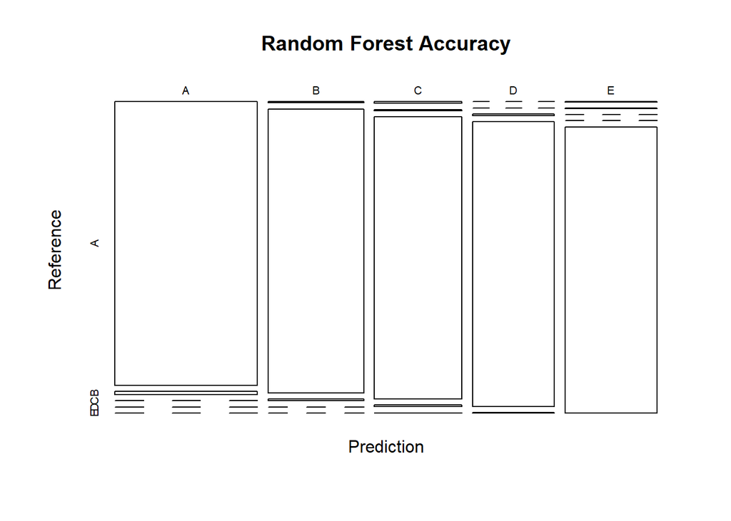

```r
plot(rfConfMatrix$table,col=rfConfMatrix$byClass,main = "Random Forest Accuracy")
```

```r
gbmModel <- train(classe~.,data = training,method="gbm",verbose=FALSE)
gbmModel$finalmodel
```

## Prediction

```r
gbmPredict <- predict(gbmModel,testing)
gbmConfMatrix <- confusionMatrix(gbmPredict,testing$classe)
gbmConfMatrix
```

```
## Confusion Matrix and Statistics
##
##           Reference
## Prediction    A    B    C    D    E
##          A 2190   73    0    0    5
##          B   16 1398   41    4   19
##          C   21   41 1305   37   16
##          D    1    1   18 1233   20
##          E    4    5    4   12 1382
##
## Overall Statistics
##
##                Accuracy : 0.9569
##                  95% CI : (0.9522, 0.9613)
##     No Information Rate : 0.2845
##     P-Value [Acc > NIR] : < 2.2e-16
##
##                   Kappa : 0.9455
##
##  Mcnemar's Test P-Value : 7.021e-14
##
## Statistics by Class:
##
##                      Class: A Class: B Class: C Class: D Class: E
## Sensitivity            0.9812   0.9209   0.9539   0.9588   0.9584
## Specificity            0.9861   0.9874   0.9822   0.9939   0.9961
## Pos Pred Value         0.9656   0.9459   0.9190   0.9686   0.9822
## Neg Pred Value         0.9925   0.9812   0.9902   0.9919   0.9907
## Prevalence             0.2845   0.1935   0.1744   0.1639   0.1838
## Detection Rate         0.2791   0.1782   0.1663   0.1572   0.1761
## Detection Prevalence   0.2891   0.1884   0.1810   0.1622   0.1793
## Balanced Accuracy      0.9836   0.9542   0.9681   0.9763   0.9772
```

- From the **Gradient Boosting Model** we see the prediction accuracy is **96%** which is satisfied.

```r
##we have taken Random Forest and Gradient Boosting Model because it reach to satisfied prediction level. we are compairing the both model which is more accurate.
rfConfMatrix$overall
```

```
##       Accuracy          Kappa  AccuracyLower  AccuracyUpper   AccuracyNull
##      0.9910783      0.9887138      0.9887412      0.9930386      0.2844762
## AccuracyPValue  McnemarPValue
##      0.0000000            NaN
```

```r
gbmConfMatrix$overall
```

```
##       Accuracy          Kappa  AccuracyLower  AccuracyUpper   AccuracyNull
##   9.569207e-01   9.454841e-01   9.521916e-01   9.613065e-01   2.844762e-01
## AccuracyPValue  McnemarPValue
##   0.000000e+00   7.020580e-14
```

## Conclusion

```r
predictTest <- predict(rfModel,testingData)
predictTest
```

```
##  [1] B A B A A E D B A A B C B A E E A B B B
## Levels: A B C D E
```